# SOS Challenge Evidence Tutorial #1

Version: 1.0.0

Marc A. Suchard

# 1 Installation

Follow the instructions on the `Hades` website on [how to set up R](https://ohdsi.github.io/Hades/rSetup.html) and [how to install HADES](https://ohdsi.github.io/Hades/installingHades.html).

While this tutorial does not use many of the `Hades` packages, these are often quite useful to have. This tutorial does require `DatabaseConnector` and `SqlRender` from `Hades`, along with `keyring`, `dplyr`, `kableExtra`, `DT` and their dependencies. These can be installed directly from CRAN.

```r
install.packages(c("SqlRender", "DatabaseConnector",
                   "keyring", "dplyr", "kableExtra"))
```

We will use `keyring` to hide database credentials. The following codes only needs to be executed once per machine.

```r
keyring::key_set_with_value("sosTutorialUser", password = "<FILL-IN>")
keyring::key_set_with_value("sosTutorialPassword", password = "<FILL-IN>")
keyring::key_set_with_value("sosTutorialServer", password = "<FILL-IN>")
```

# 2 Access and schema

We hold the SOS Challenge results on the OHDSI public database server `shinydb`. The web-page at [https://bit.ly/strategus_data_model](https://ohdsi.github.io/SosTutorial/StrategusDataModel.html) describes the data models for `Strategus` modules and some instructions on how to access results in these models. Our database server runs `postgresql`. You can install the `postgresql` JDBC drivers; this only needs to be done once.

It is recommend to specify the environmental variable `DATABASECONNECT_JAR_FOLDER=<folder-of-your-choice>` in `.Renviron` located in the user’s home directory. In the example below, however, we set the environmental variable manually in `R` to make this document more self-contained.

```r
Sys.setenv(DATABASECONNECTOR_JAR_FOLDER = getwd())
DatabaseConnector::downloadJdbcDrivers(dbms = "postgresql")
```

and set-up connection details, in this case using `keyring` to hide usernames and passwords for security`

```r
# OHDSI shinydb read-only credentials
connectionDetails <- DatabaseConnector::createConnectionDetails(
  dbms = "postgresql",
  server = keyring::key_get("sosTutorialServer"),
  user = keyring::key_get("sosTutorialUser"),
  password = keyring::key_get("sosTutorialPassword"))
```

Table 2.1 provides the `schema` names for SOS Challenge results.

Table 2.1: SOS Challenge study schema

| SOS Challenge study | schema |
| --- | --- |
| Fluoroquinolone and aortic aneurysms | quinoloneaa |
| Intravitreal anti-VEGF and kidney failure | antivegfkf |

# 3 Retrieving database meta-data

We will use the `Hades` packages `DatabaseConnector` and `SqlRender` to query the results tables directly in `R`.  
Many `join`s and column-`select` can be done either on the server-side (`postgresql`) or client-side (`R`). We prefer the server-side when accessing large tables. On the client-side, `dplyr` is effective.

Here is an example of a basic query to `database_meta_data` to return data-source names and abbreviations (with client-side `select`):

```r
schema <- "quinoloneaa"

connection <- DatabaseConnector::connect(connectionDetails = connectionDetails)

sql <- SqlRender::render(sql = "
  SELECT * FROM @schema.database_meta_data",
  schema = schema) # parameterized

metaData <- DatabaseConnector::querySql(connection = connection,
                                        sql = sql,
                                        snakeCaseToCamelCase = TRUE)

DatabaseConnector::disconnect(connection)

names(metaData)
```

```
##  [1] "cdmSourceName"                "cdmSourceAbbreviation"
##  [3] "cdmHolder"                    "sourceDescription"
##  [5] "sourceDocumentationReference" "cdmEtlReference"
##  [7] "sourceReleaseDate"            "cdmReleaseDate"
##  [9] "cdmVersion"                   "cdmVersionConceptId"
## [11] "vocabularyVersion"            "databaseId"
## [13] "maxObsPeriodEndDate"
```

```r
library(dplyr)
databaseName <- metaData %>% select(cdmSourceAbbreviation, databaseId)
databaseName
```

| cdmSourceAbbreviation | databaseId |
| --- | --- |
| JMDC | -813817418 |
| IBM MDCD | -1580117986 |
| ausom | -795494529 |
| NHIS-NSC | -951586871 |
| OPTUM Extended DOD | 1259696173 |
| Optum EHR | -1438081874 |
| PharMetrics | 1222091397 |
| TMUDB | 788041954 |
| VA-OMOP | -7753527 |
| Epic Legacy CUMC MERGE | 1669783991 |

[output cut: 7 more lines]

Now is a good time to (manually) change the abbreviations in `databaseName` to consistent, similar-length, reader-friendly choices for our manuscript(s).

```r
databaseName$shortDatabaseName <- c("JMDC", "MDCD", "Ausom", "NHIS", "OptumDOD",
                                    "OptumEHR", "PhM", "TMU", "VA", "CUMC", "Sev",
                                    "Italy", "Belgium", "Australia", "Japan", "Germany",
                                    "CCAE")
```

Likewise, we retrieve reader-friendly cohort names. Note that the following codes does not return negative control cohort names; these are not (?) currently stored in the results-set.

```r
connection <- DatabaseConnector::connect(connectionDetails = connectionDetails)
sql <- SqlRender::render(sql = "
  SELECT DISTINCT cohort_id, cohort_name FROM @schema.cg_cohort_generation",
  schema = schema)

cohortName <- DatabaseConnector::querySql(connection = connection,
                                            sql = sql,
                                            snakeCaseToCamelCase = TRUE)

DatabaseConnector::disconnect(connection)
```

```r
cohortName$shortCohortName <- c("AD", "UTI", "Cef", "AA", "FQ", "FQ2",
                                "UTI2", "Cef2", "TMP", "AA/AD", "TMP2")

DT::datatable(cohortName)
```

|  | cohortId | cohortName | shortCohortName |
| --- | --- | --- | --- |
| 1 | 1782488001 | [SOS Phenotype Devt] Fluoroquinolone systemic exposures with urinary tract infection - in cohorts: (1782485) starts within D: -99999 - D: 0 of cohort start and ends D: -99999 - D: 99999 of cohort star… | AD |
| 2 | 1782670 | [SOS Phenotype Devt] trimethoprim systemic exposures with urinary tract infection | UTI |
| 3 | 1782489 | [SOS Phenotype devt] Aortic aneurysm or aortic dissection events inpatient | Cef |
| 4 | 1782487001 | [SOS Phenotype Devt] Cephalosporin systemic exposures with urinary tract infection - in cohorts: (1782485) starts within D: -99999 - D: 0 of cohort start and ends D: -99999 - D: 99999 of cohort start,… | AA |
| 5 | 1782487 | [SOS Phenotype Devt] Cephalosporin systemic exposures with urinary tract infection | FQ |
| 6 | 1782488 | [SOS Phenotype Devt] Fluoroquinolone systemic exposures with urinary tract infection | FQ2 |
| 7 | 1782670001 | [SOS Phenotype Devt] trimethoprim systemic exposures with urinary tract infection - in cohorts: (1782485) starts within D: -99999 - D: 0 of cohort start and ends D: -99999 - D: 99999 of cohort start, … | UTI2 |
| 8 | 1782671 | [SOS Phenotype devt] Aortic aneurysm events inpatient | Cef2 |
| 9 | 1782485101 | [SOS Phenotype Devt] Urinary tract infections - first ever occurence with at least 365 days prior observation and 1 days follow up observation, males, females aged 35+, occurs after 2010-01-01 and bef… | TMP |
| 10 | 1782672 | [SOS Phenotype devt] Aortic dissection events inpatient | AA/AD |

[output cut: 1 more lines]

# 4 Basic results queries

Here is an example of a basic query to a `cohort_counts` table to return cohort sizes. We then output the counts using a well-formatted table

```r
connection <- DatabaseConnector::connect(connectionDetails = connectionDetails)
sql <- SqlRender::render(sql = "
  SELECT database_id, cohort_id, cohort_subjects FROM @schema.cg_cohort_count",
  schema = schema)

cohortCount <- DatabaseConnector::querySql(connection = connection,
                                            sql = sql,
                                            snakeCaseToCamelCase = TRUE) %>%
  inner_join(databaseName, by = "databaseId") %>%
  inner_join(cohortName, by = "cohortId") %>%
  select(shortCohortName, shortDatabaseName, cohortSubjects) %>%
  rename(cohortName = shortCohortName, databaseName = shortDatabaseName) %>%
  arrange(cohortName,  databaseName)

DatabaseConnector::disconnect(connection)
```

## 4.1 Hints for beautiful tables

The `kableExtra` package (especially when printed to PDF) makes beautiful tables.

```r
table <- cohortCount %>% filter(cohortName %in% c("FQ", "TMP")) %>%
  rename(Cohort = cohortName, Database = databaseName, Subjects = cohortSubjects) %>%
  mutate(Subjects = prettyNum(Subjects,
                              format = "d",
                              big.mark = ",")) %>% # Can easily change for _Lancet_
  tidyr::spread(Cohort, Subjects)

tab <- table %>% kbl(align = "lrr") %>% kable_classic(full_width = F) %>%
  add_header_above(c(" " = 1, "Exposure" = 2)) %>%
  row_spec(0, align = "c")

if (knitr::is_latex_output()) {
  tab %>% kable_styling(latex_options = "striped",
                          font_size = latex_table_font_size)
} else {
  tab ## bootstrap-striped is not nicely compatible with `add_header_above`
}
```

| Database | Exposure FQ | Exposure TMP |
| --- | --- | --- |
| Ausom | 7,145 | 3,112 |
| Australia | 61,643 | 18,494 |
| Belgium | 1,779 | 12,780 |
| CCAE | 1,808,840 | 2,643,263 |
| CUMC | 39,300 | 45,090 |
| Germany | 148,887 | 333,640 |
| Italy | 19,016 | 60,261 |
| Japan | 125,922 | 237,237 |
| JMDC | 66,491 | 61,959 |
| MDCD | 1,089,470 | 674,206 |
| NHIS | 35,556 | 28,949 |
| OptumDOD | 1,766,883 | 2,425,700 |
| OptumEHR | 1,628,277 | 3,251,539 |
| PhM | 1,911,067 | 2,457,352 |
| Sev | 21,235 | 15,818 |
| TMU | 117,989 | 68,334 |
| VA | 251,963 | 653,418 |

Often it is most convenient to hand-craft `latex` table headers and footers and `cat` this material directly to the output. Here is a silly example.

```r
# Requires "results='asis'"

library(xtable)
cat(gsub("\\\\", "\\", r"{
  \begin{table}[h]
  \begin{center}
  \begin{tabular}{lrr}
  \hline
  \multicolumn{1}{c}{$\alpha$} & \multicolumn{1}{c}{$\beta$} & \multicolumn{1}{c}{$\delta$} \\\\
}", fixed = TRUE))

print(xtable(table, format = "latex"),
      include.rownames = FALSE, include.colnames = FALSE, only.contents = TRUE)

cat(gsub("\\\\", "\\", r"{
  \end{tabular}
  \end{center}
  \caption{A silly caption with \LaTeX commands}
  \end{table}
}", fixed = TRUE))
```

Note that if one abhors escaping backslash-characters, then one can read the header and footer from text files.

# 5 Working with `CohortMethod`

Unfortunately, we currently do *not* have a shared repository of functions to generate typical results figures and tables. Even `OhdsiShinyModules` hides these tools inside inaccessible `shiny`-functions. Until we solve this limitation, we recommend duplicating code from previous public manuscripts. The `LegendT2dmEvidenceExplorer` from LEGEND-T2DM is a good example: [`getCovariateBalance()`](https://github.com/ohdsi-studies/LegendT2dmEvidenceExplorer/blob/b3564ea3c8257817d92de24b0f2244fed1df1f99/inst/shiny/DataPulls.R#L331)

## 5.1 Query the design choices and comparisons

```r
connection <- DatabaseConnector::connect(connectionDetails)

sql <- paste0("SET search_path TO ", schema, ";")
DatabaseConnector::executeSql(connection = connection, sql = sql)

sql <- "
  SELECT DISTINCT target_id, comparator_id,
    cm_analysis.analysis_id, cm_analysis.description
  FROM cm_covariate_balance
  INNER JOIN cm_analysis
  ON cm_analysis.analysis_id = cm_covariate_balance.analysis_id"

analysis <- DatabaseConnector::querySql(connection = connection,
                                        sql = sql,
                                        snakeCaseToCamelCase = TRUE)

DatabaseConnector::disconnect(connection)

datatable(analysis %>% arrange(analysisId, targetId, comparatorId))
```

|  | targetId | comparatorId | analysisId | description |
| --- | --- | --- | --- | --- |
| 1 | 1782488001 | 1782487001 | 1 | Cohort method, 30d fixed window |
| 2 | 1782488001 | 1782670001 | 1 | Cohort method, 30d fixed window |
| 3 | 1782488001 | 1782487001 | 2 | Cohort method, 60d fixed window |
| 4 | 1782488001 | 1782670001 | 2 | Cohort method, 60d fixed window |
| 5 | 1782488001 | 1782487001 | 3 | Cohort method, 90d fixed window |
| 6 | 1782488001 | 1782670001 | 3 | Cohort method, 90d fixed window |
| 7 | 1782488001 | 1782487001 | 4 | Cohort method, 365d fixed window |
| 8 | 1782488001 | 1782670001 | 4 | Cohort method, 365d fixed window |

## 5.2 Covariate balance

Shamelessly (until these functions are exported) stolen from [`OhdsiStudyModules/R`](https://github.com/OHDSI/OhdsiShinyModules/tree/main/R):

```r
# Stolen from `OhdsiShinyModules`
getCovariateBalance <- function(connection, schema,
                                targetId,
                                comparatorId,
                                analysisId,
                                databaseId,
                                outcomeId) {
  sql <- "
      SELECT
        cmcb.database_id,
        cmcb.covariate_id,
        cmc.covariate_name,
        cmc.covariate_analysis_id analysis_id,
        cmcb.target_mean_before before_matching_mean_treated,
        cmcb.comparator_mean_before before_matching_mean_comparator,
        abs(cmcb.std_diff_before) abs_before_matching_std_diff,
        cmcb.target_mean_after after_matching_mean_treated,
        cmcb.comparator_mean_after after_matching_mean_comparator,
        abs(cmcb.std_diff_after) abs_after_matching_std_diff
      FROM
        (select * from  @results_schema.@table_prefixcovariate_balance
        WHERE target_id = @target_id
        AND comparator_id = @comparator_id
        AND outcome_id = @outcome_id
        AND analysis_id = @analysis_id
        AND database_id = '@database_id'
        ) as cmcb
        INNER JOIN @results_schema.@table_prefixcovariate cmc
          ON cmcb.covariate_id = cmc.covariate_id
          AND cmcb.analysis_id = cmc.analysis_id
          AND cmcb.database_id = cmc.database_id"

  sql <- SqlRender::render(sql,
                           target_id = targetId,
                           comparator_id = comparatorId,
                           database_id = databaseId,
                           results_schema = schema,
                           table_prefix = "cm_",
                           analysis_id = analysisId,
                           outcome_id = outcomeId)

  balance <- DatabaseConnector::querySql(connection, sql,
                                         snakeCaseToCamelCase = TRUE)
  return(balance)
}
```

```r
connection <- DatabaseConnector::connect(connectionDetails)

balance <- getCovariateBalance(connection, schema,
                               targetId = 1782488001,     # FQ2
                               comparatorId = 1782487001, # Cef2
                               analysisId = 2,
                               databaseId = -7753527,     # VA
                               outcomeId = 1782489)       # AA/AD

DatabaseConnector::disconnect(connection)

datatable(balance %>% select(-databaseId, -analysisId),
          colnames = c("ID", "Name", "bT", "bC", "bSD", "aT", "aC", "aSD"),
          rownames = NULL)
```

| ID | Name | bT | bC | bSD | aT | aC | aSD |
| --- | --- | --- | --- | --- | --- | --- | --- |
| 1901 | Charlson index - Romano adaptation | 4.159 | 5.405 | 0.338 | 5.134 | 4.993 | 0.038 |
| 1902 | Diabetes Comorbidity Severity Index (DCSI) | 3.55 | 4.533 | 0.294 | 4.336 | 4.228 | 0.032 |
| 21602796410 | drug_era group during day -365 through 0 days relative to index: ANTIBACTERIALS FOR SYSTEMIC USE | 0.52 | 0.663 | 0.294 | 0.636 | 0.609 | 0.055 |
| 21600960410 | drug_era group during day -365 through 0 days relative to index: ANTITHROMBOTIC AGENTS | 0.462 | 0.599 | 0.278 | 0.572 | 0.558 | 0.028 |
| 1904 | CHADS2VASc | 2.962 | 3.438 | 0.266 | 3.349 | 3.29 | 0.033 |
| 4030518210 | condition_era group during day -365 through 0 days relative to index: Renal impairment | 0.214 | 0.317 | 0.234 | 0.294 | 0.284 | 0.023 |
| 321588210 | condition_era group during day -365 through 0 days relative to index: Heart disease | 0.4 | 0.493 | 0.187 | 0.475 | 0.463 | 0.024 |
| 316139210 | condition_era group during day -365 through 0 days relative to index: Heart failure | 0.117 | 0.18 | 0.179 | 0.167 | 0.16 | 0.018 |
| 4182210210 | condition_era group during day -365 through 0 days relative to index: Dementia | 0.068 | 0.119 | 0.178 | 0.103 | 0.102 | 0.004 |
| 313217210 | condition_era group during day -365 through 0 days relative to index: Atrial fibrillation | 0.112 | 0.173 | 0.175 | 0.16 | 0.156 | 0.011 |

[output cut: 81 more lines]

It remains straight-forward to adapt existing plots or generate one’s own.

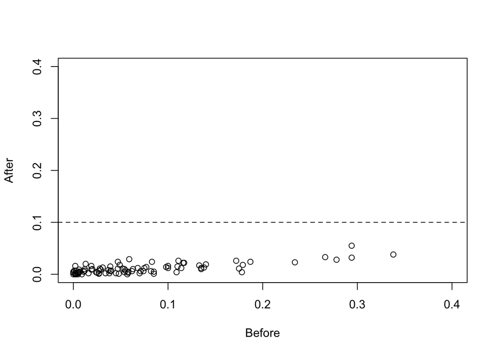

```r
plot(balance$absBeforeMatchingStdDiff, balance$absAfterMatchingStdDiff,
     xlim = c(0, 0.4), ylim = c(0, 0.4),
     xlab = "Before", ylab = "After")
abline(h = 0.1, lty = 2)
```

When saving figures to disk, use a vector-graphic format (e.g., PDF), as these formats can scale to any size without resolution loss. For `R-base` plotting, the relevant functions are `pdf()` and `dev.off()`. For `gg` plotting, use `ggsave(filename = "<NAME>.pdf")`.

## 5.3 Effect estimates

```r
connection <- DatabaseConnector::connect(connectionDetails)

sql <- paste0("SET search_path TO ", schema, ";")
DatabaseConnector::executeSql(connection = connection, sql = sql)

cmResult <- DatabaseConnector::querySql(connection = connection,
                                        sql = "SELECT * FROM cm_result",
                                        snakeCaseToCamelCase = TRUE)

cmDiagnostics <- DatabaseConnector::querySql(connection = connection,
                                        sql = "SELECT * FROM cm_diagnostics_summary",
                                        snakeCaseToCamelCase = TRUE)

DatabaseConnector::disconnect(connection)

subset <- cmResult %>%
  filter(outcomeId %in% c(1782489, 1782671, 1782672),         # All outcomes
         targetId == 1782488001, comparatorId == 1782487001,  # FQ2 vs Cef2
         analysisId == 2) %>%
  inner_join(cmDiagnostics %>%
               select(databaseId, analysisId, targetId, comparatorId, outcomeId, unblind)) %>%
  inner_join(databaseName %>%
               select(databaseId, shortDatabaseName) %>%
               rename(databaseName = shortDatabaseName) %>%
               mutate(minorOrder = row_number()))

# Uses a custom function from the LEGEND-T2DM manuscript package
makePrettyFigure(subset %>%
                   mutate(majorOrder = 1,
                          pass = unblind,
                          cumMajorSkip = 0),
                 fileName = "SosFigure1.pdf",
                 outcomeIds = c(1782489,1782671,1782672),
                 outcomeNames = c("AA/AD", "AA", "AD"))
```

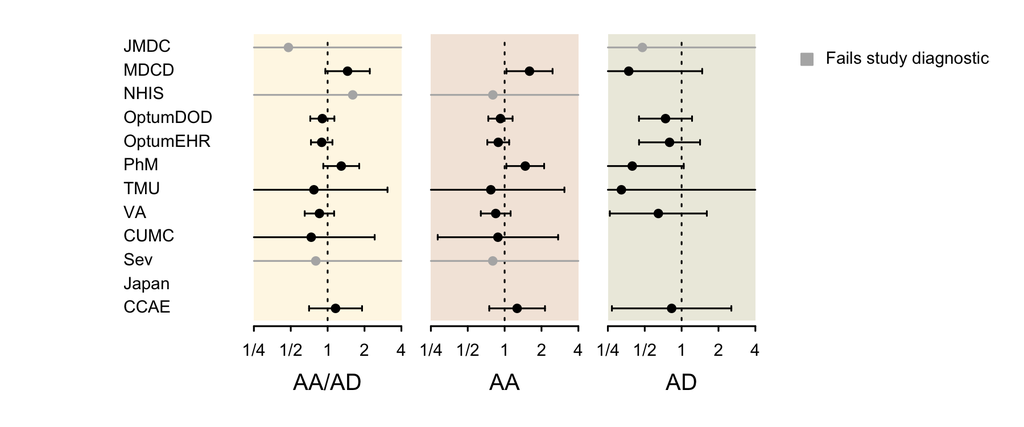

Figure 5.1: Custom plotting function reporting hazard ratio (HR) and 95% confidence interval estimates across data sources. Note the beautiful `wesanderson` inspired colors.